# Understanding Migration Patterns in Bolivia

##### Origins of Internal Migrants

After understanding the preferred destinations of Bolivia’s internal migrants, it’s equally crucial to delve into their points of origin. Knowing where people are migrating from can offer a complementary perspective, shedding light on regions that might be experiencing population outflows and the possible reasons behind them.

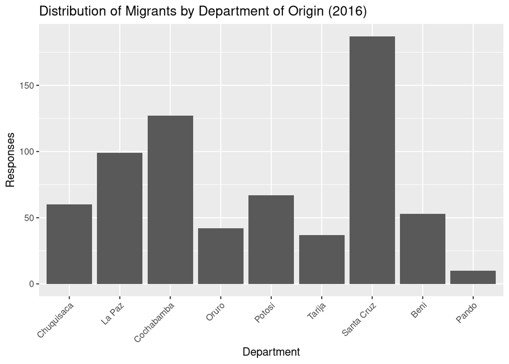

Figure 33: Distribution of Migrants by Department of Origin (2016)

##### Net Migratory Change

Having explored the distinct dimensions of where people are migrating to and from, it’s essential to consolidate these findings. By juxtaposing the inflow and outflow of migrants, we can determine the net migratory change for each department, providing a holistic understanding of migration dynamics within Bolivia.

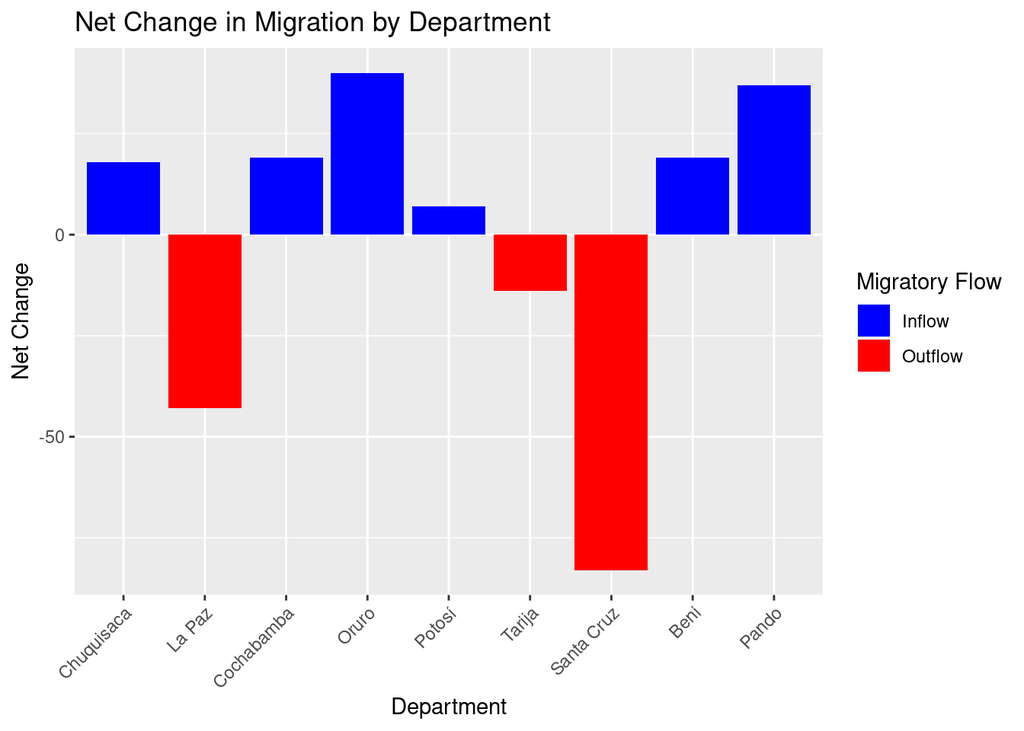

Figure 34: Net Migratory Change by Department

The composite view offers several intriguing revelations. Most prominently, Santa Cruz exhibits the highest migratory difference, but it’s skewed towards emigration, suggesting a net outflow from the department. Similarly, La Paz is witnessing a population drain. Contrarily, nearly every other department showcases positive immigration, indicating they’re attracting more residents than they’re losing. This pattern is particularly unexpected and runs counter to initial hypotheses. However, it’s crucial to approach these findings with caution, considering the relatively limited number of responses that might not capture the full spectrum of Bolivia’s internal migration landscape.

##### Internal Migratory Patterns by Sex

It’s crucial to explore another dimension of Bolivia’s internal migration: the gender dynamics. By understanding how male and female migrants distribute across departments, we can gain insights into any gender-specific patterns that might emerge. Let’s examine a representation of the current residence of migrants, segmented by gender, to unveil any such trends.

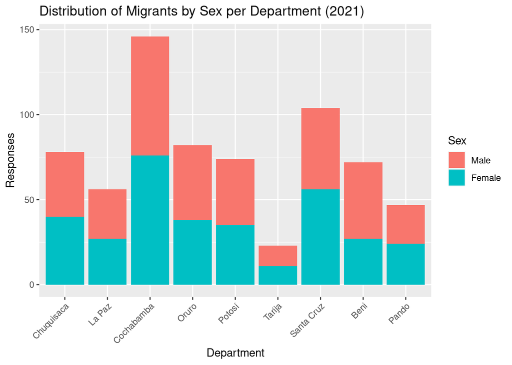

Figure 35: Gender Distribution Across Departments for Internal Migrants since 2016.

##### Average Age of Migrants within Bolivia

After examining the gender distribution of internal migrants across various departments, it’s essential to delve into another demographic facet: age. Age can provide insights into whether younger populations are more mobile or if older generations are relocating for various reasons. In the forthcoming analysis, we’ll explore the average age of migrants within each department to shed light on these patterns.

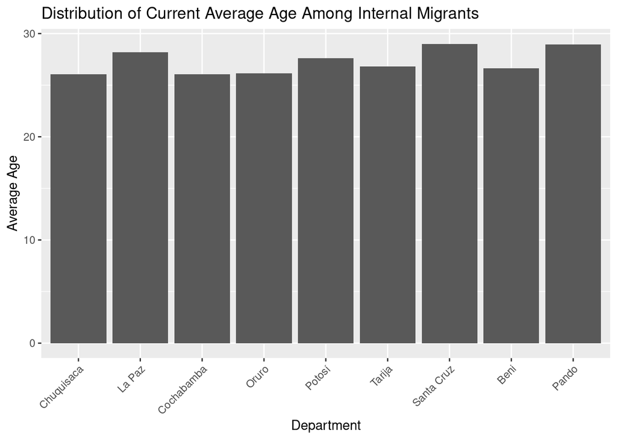

Figure 36: Distribution of the Current Average Age of Migrants within Bolivia.

The average age of migrants in Bolivia varies slightly across departments. Santa Cruz leads the chart with an average age of approximately 29, closely followed by Pando. This might suggest a certain age group being more inclined to migrate to these areas, possibly for employment, education, or other opportunities. Conversely, Chuquisaca, with the lowest average age among migrants, might attract younger individuals. Overall, the age distribution is relatively consistent across departments, with most averages hovering around the late twenties.

##### Reasons for Migration Within Bolivia

Beyond the demographic elements of age and gender, understanding the reasons why people migrate offers profound insights into the socio-economic and cultural factors influencing their decisions. Are they moving for job opportunities, education, family reasons, or other drivers? In the subsequent analysis, we’ll enumerate the reasons given by respondents for their internal migrations within Bolivia.

Table 6: Reasons for Internal Migration

| Reason | Count |
| --- | --- |
| Job Search | 255 |
| Work Transfer | 172 |
| Education | 125 |
| Health | 46 |
| Family Reason | 688 |
| Other Reason (Specify) | 25 |
| NA | 43 |

The predominant reason for internal migration within Bolivia, as revealed by the respondents, is for “Family Reasons”, accounting for a significant portion of the migrations. This underscores the role of familial ties in influencing mobility decisions. In second place, “Job Search” is a key driver, followed closely by “Work Transfer”, suggesting employment opportunities and changes play pivotal roles in migration. Additionally, “Education” and “Health” indicate that access to better facilities or institutions can also be compelling reasons to relocate. It’s worth noting that a segment of respondents cited other unspecified reasons, underscoring the myriad personal and unique factors that can contribute to the decision to migrate.

##### Labor and Employment of Migrants within Bolivia

As we navigate deeper into understanding the occupational landscapes of internal migrants within Bolivia, it becomes vital to discern the predominant professions in each department. Recognizing these patterns not only provides insights into the local economic environment but also uncovers the potential opportunities or challenges that might influence migratory decisions.

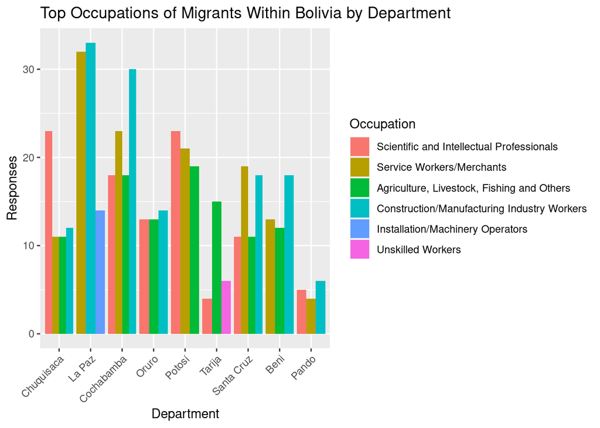

Figure 37: Distribution of the Top Three Occupations in Each Department for Internal Migrants within Bolivia.

In essence, the occupational trends of recent migrants offer a lens into the dynamic economic landscapes of Bolivia’s departments and provide clues about the driving forces behind internal migration patterns since 2016. Both Oruro and Potosi are home to some of the world’s largest reserves of lithium which may hint at future migratory pattern shifts.

##### Average Current Income of Internal Migrants

As we continue to unravel the intricacies of internal migration within Bolivia, economic factors naturally come to the forefront. The allure of better job opportunities, higher wages, or even the promise of a more comfortable lifestyle can be compelling reasons for individuals to relocate. To shed light on this dimension, let’s delve into the average monthly incomes across different departments, specifically focusing on those who’ve migrated within Bolivia since 2016. This will provide a clearer picture of the financial landscapes that may be influencing migratory decisions.

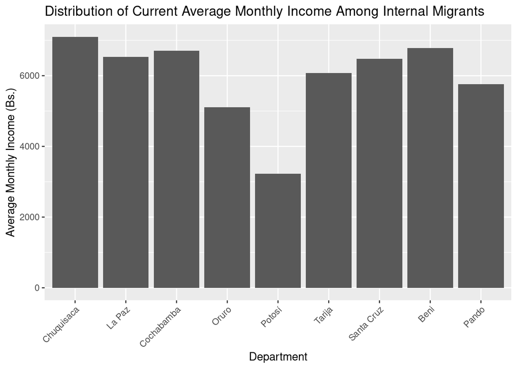

Figure 38: Distribution of Average Monthly Income by Department of Internal Migrants.

##### Summary Conclusion of Internal Migrants Analysis

When juxtaposing the internal migration patterns with those of the internationally repatriated migrants, several noteworthy contrasts emerge. A glance at the age demographics reveals that migrants returning from abroad tend to fall into a slightly older age bracket. Countries such as Paraguay, Italy, and the USA had returnees averaging around the age of 50, possibly indicating a trend of Bolivians returning post-retirement or after a long professional stint abroad.

In essence, while spending time abroad did offer advantages to some in terms of enhanced career prospects upon return, it wasn’t a universal experience. The benefits of international migration appear to be contingent on several factors, including the country of stay, the duration of time spent there, and the nature of skills or experiences gained.

In closing, the national migratory patterns in Bolivia are a testament to the interplay of various socio-economic factors. From professional opportunities to economic allure, myriad reasons influence the decisions of Bolivians to move within their homeland. As we transition into a deeper exploration of migration patterns in Santa Cruz, these insights set the stage for a more nuanced understanding of the dynamics at play.

#### Migratory Patterns of Santa Cruz

Santa Cruz, as Bolivia’s largest department and a significant economic hub, warrants a closer examination of its migratory patterns. While the overarching analysis has provided insights into the broader national context, focusing on Santa Cruz allows us to understand the nuances of migration specific to this region. Within this deep dive, we’ll explore various facets of the migrants that choose to leave or come to Santa Cruz, including:

**Gender Distribution:** How do the migratory patterns differ between males and females? Is there a significant gender skew in the migrants?

**Population Type:** Are migrants predominantly from urban or rural backgrounds? How does this distinction play a role in their movement?

**Occupation:**What sectors or industries are most represented among the migrants? Do certain occupations have a higher propensity to migrate?

**Income Levels:** How do the income levels of migrants compare to those who remain? Is economic motivation a significant driver for movement?

By dissecting these areas, we hope to piece together a comprehensive picture of Santa Cruz’s migratory landscape, shedding light on the factors that drive or deter movement in and out of the department.

##### Origin of Migrants into Santa Cruz

Santa Cruz stands as a pivotal hub in Bolivia’s migratory matrix. Its economic dynamism, diverse opportunities, and cultural vibrancy make it a magnet for both international and internal migrants. As we shift our analytical focus to Santa Cruz, a crucial question arises: From which Bolivian regions are people arriving to settle in this bustling department?

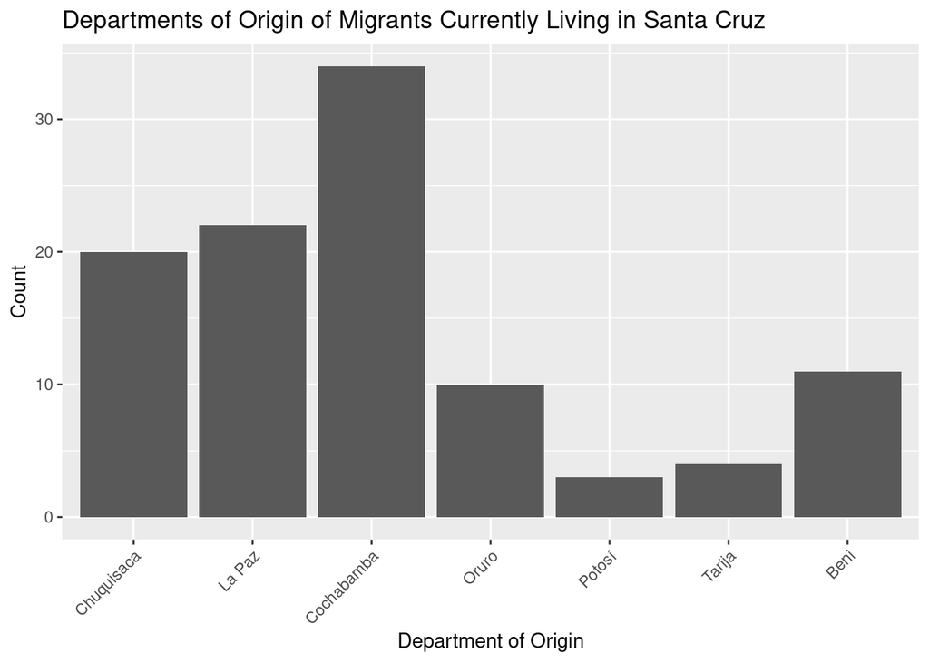

Figure 39: Distribution of Migrants into Santa Cruz by Department of Origin.

Santa Cruz’s allure seems to resonate most with residents of Cochabamba, with over 30 individuals migrating from this region alone. La Paz and Chuquisaca also contribute significantly to the migratory influx into Santa Cruz. Interestingly, Potosi, despite its rich cultural and historical significance, has the smallest representation among migrants to Santa Cruz. This distribution could hint at socio-economic or lifestyle factors driving migration, as people seek better opportunities or a change in their living environment.

##### Sex of Migrants into Santa Cruz

Having delved into the broader reasons for migration to Santa Cruz, it’s intriguing to consider how gender dynamics might play a role in these patterns. Could certain regions display gender-specific trends in their migration to Santa Cruz?

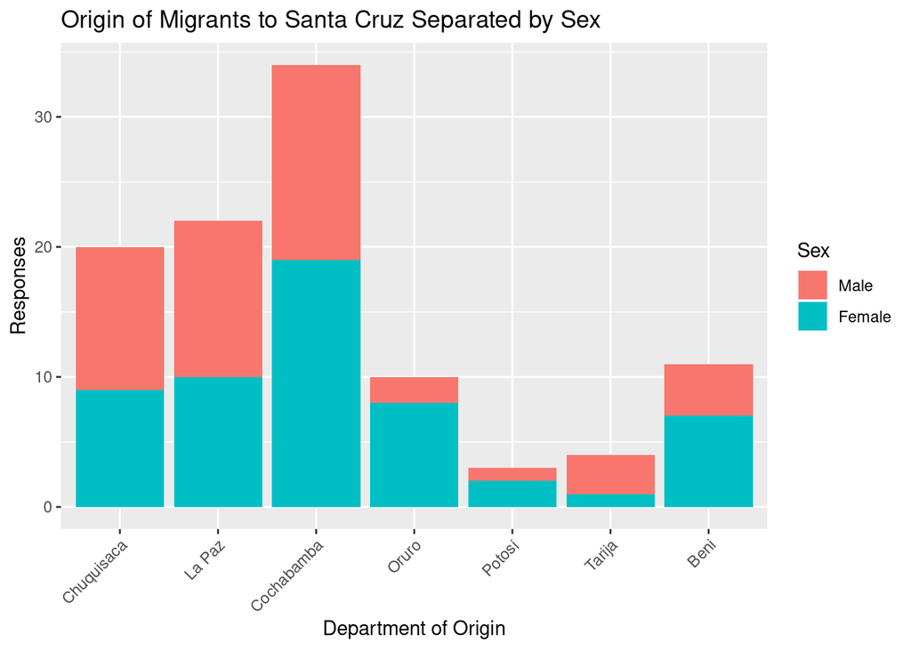

Figure 40: Origin of Migrants to Santa Cruz, Segregated by Sex

The migration landscape to Santa Cruz, when observed through the lens of gender, reveals some distinctive patterns. Most regions exhibit a balanced gender distribution among migrants. However, Potosi and Oruro stand out with a predominant female migratory trend, raising questions about specific socio-economic or cultural factors in those regions that might influence such a trend. Conversely, Tarija’s migration to Santa Cruz leans heavily towards men. These gender-specific variances offer a richer understanding of the intricate fabric of migration to Santa Cruz and hint at underlying regional narratives that could be influencing these patterns.

##### Reasons for Migration

Having understood the geographical origins of migrants to Santa Cruz, it’s essential to uncover the motivations driving this movement. What personal or professional reasons lead individuals to relocate to this dynamic department?

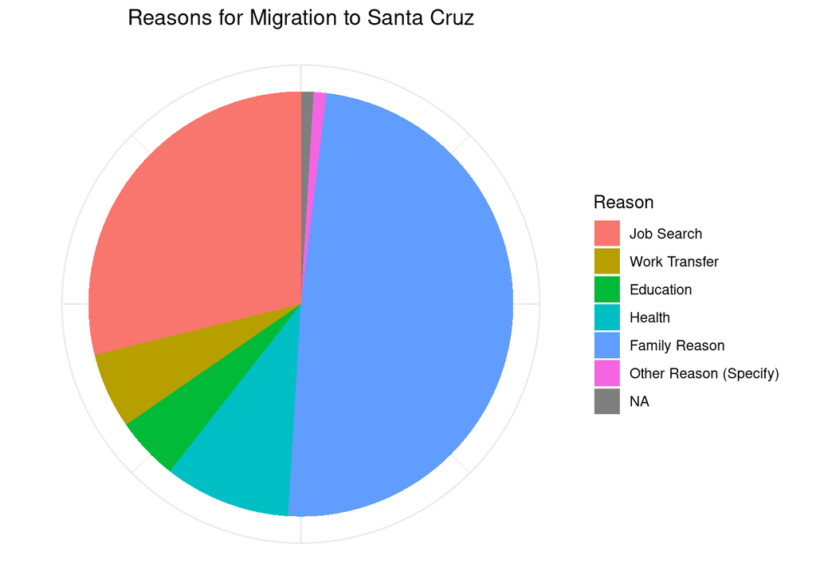

Figure 41: Reasons for Migration to Santa Cruz.

Family ties stand as the cornerstone of migration to Santa Cruz, with the majority citing family reasons as their primary motivation. This showcases the importance of familial bonds and perhaps the desire to be closer to loved ones. Following closely is the allure of employment opportunities, underscoring Santa Cruz’s reputation as an economic powerhouse in Bolivia. The combination of these reasons paints a picture of Santa Cruz as a region that offers both familial warmth and professional growth.

##### Migrants Moving Out of Santa Cruz

While Santa Cruz attracts a significant number of migrants, it’s equally crucial to understand its outward migratory patterns. What drives the people of Santa Cruz to seek new horizons, and which regions appeal to them the most?

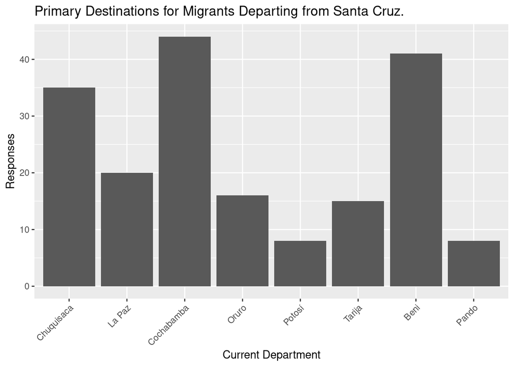

Figure 42: Primary Destinations for Migrants Departing from Santa Cruz.

##### Sex of Outbound Migrants

Diving deeper into the migration patterns from Santa Cruz, we also investigate if gender plays any significant role in influencing these decisions. Do men and women from Santa Cruz show distinct preferences in their chosen destinations?

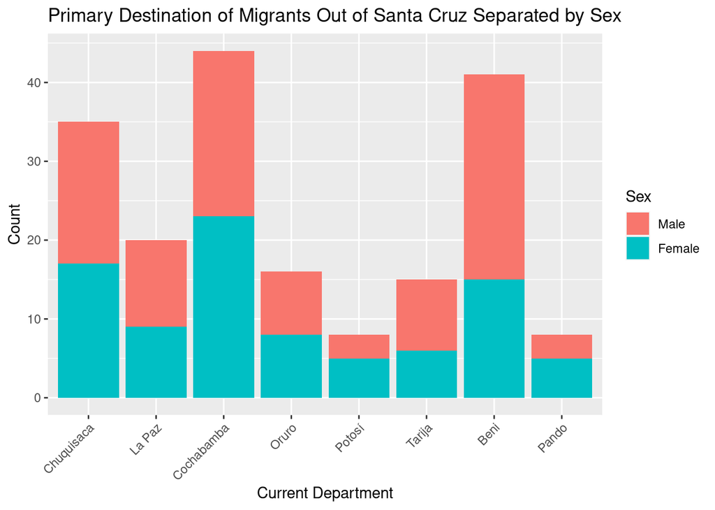

Figure 43: Gender Distribution of Migrants Departing from Santa Cruz by Destination.

When delving into the gender nuances of those departing from Santa Cruz, the distinctions are subtle but telling. While many destinations show an even spread between male and female migrants, certain departments like Potosi and Pando see a slight inclination towards women, whereas Tarija and Beni observe a male-dominant trend. These slight divergences suggest that while many migration influencers may be broadly gender-neutral, specific factors or conditions in certain areas might appeal differently to men and women. With these gender dynamics in mind, it prompts the question: could marital or civil status play a role in these migration patterns? Let’s further explore this angle in the subsequent analysis.

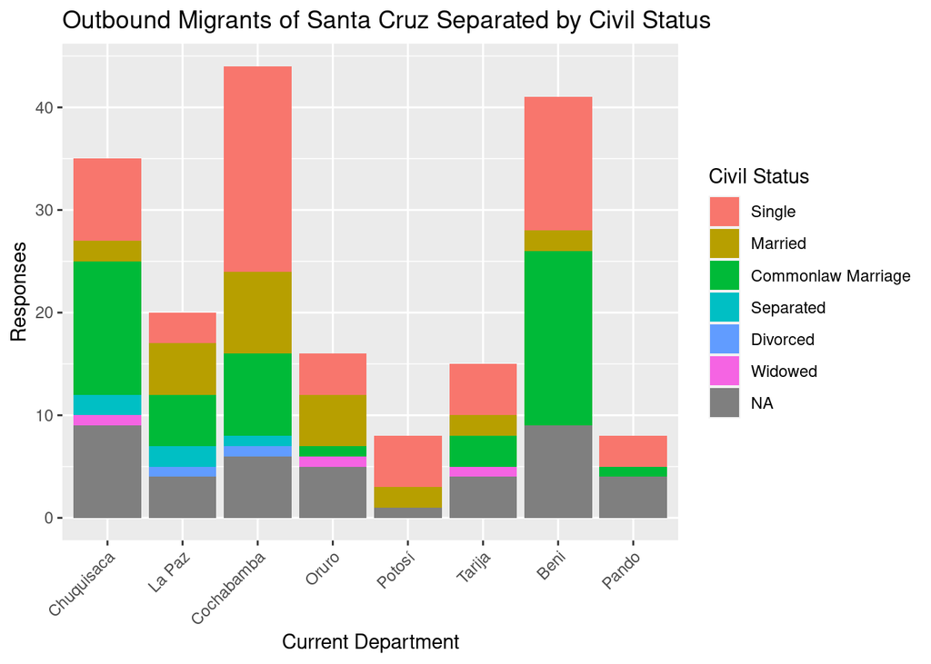

Figure 44: Distribution of Migrants Departing Santa Cruz Separated by Civil Status

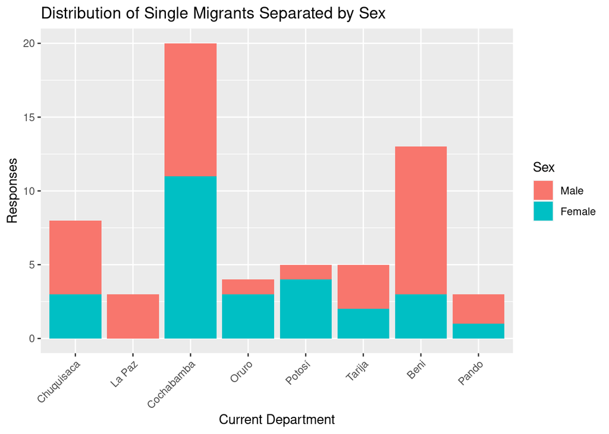

Figure 45: Distribution of Single Migrants Separated by Sex.

When focusing on single migrants departing from Santa Cruz, a distinct pattern emerges. La Paz stands out with only male migrants leaving Santa Cruz, suggesting potential occupational or lifestyle choices unique to single men. Chuquisaca and notably Beni also see a male dominance, aligning with the occupation types common in these areas. On the flip side, Oruro and Potosi witness a substantial female majority among single migrants. The most balanced distribution is observed in Cochabamba, where the numbers of male and female single migrants are almost equal, reflecting the dynamics between two major urban centers.

##### Previous Population Types of Migrants into Santa Cruz

Are migrants predominantly coming from urban hubs, bustling with activity, or are they hailing from more tranquil rural settings? Understanding the population type of their previous and current residence might shed light on what these individuals seek in Santa Cruz. The next figure provides a breakdown of where these migrants previously resided, offering insights into the urban-rural dynamics at play.

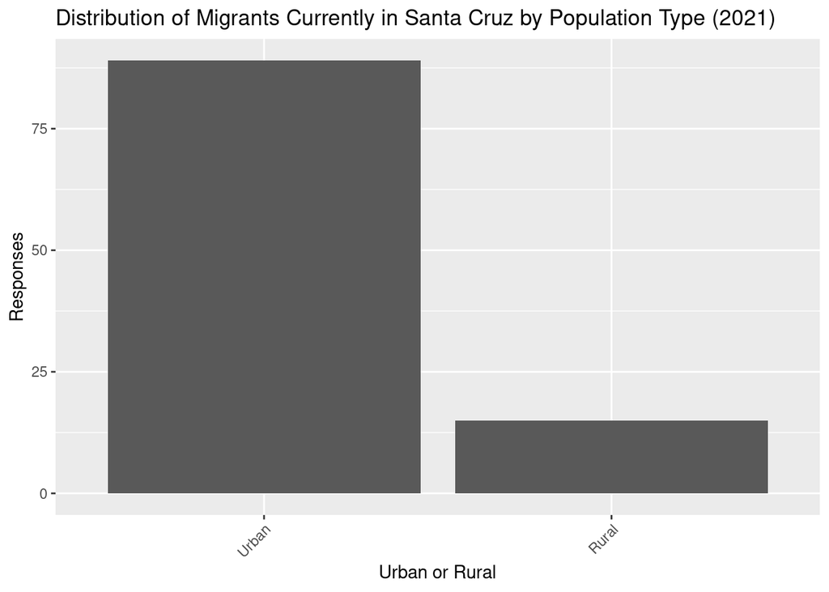

Figure 46: Distribution of Migrants Currently in Santa Cruz by Population Type (2021)

The data indicates a pronounced preference for urban areas, with a substantial majority of respondents settling in urban centers. This trend is likely driven by the allure of Santa Cruz de la Sierra (the capital city of the department, not to be confused with the department of Santa Cruz), which stands as a beacon of economic and social opportunities.

Transitioning from this, it would be insightful to explore the type of environments these migrants have moved from. Are they primarily from other urban areas, or is there a significant shift from rural to urban living in their migration patterns?

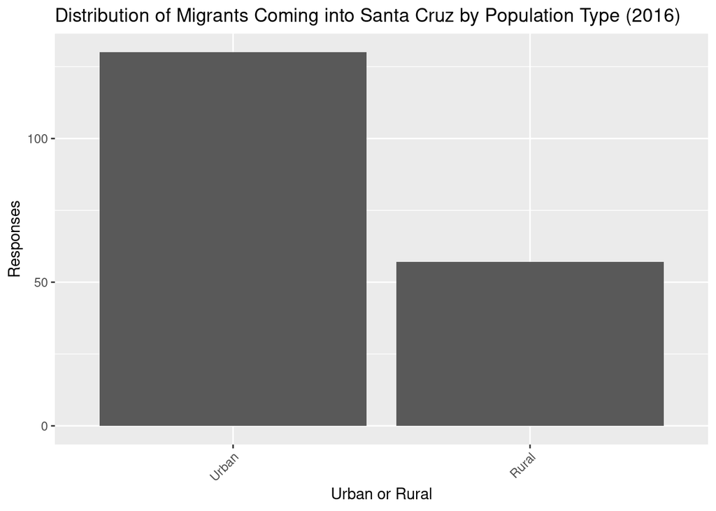

#### Employment and Occupation of Migrants into Santa Cruz

Let’s explore the labor dynamics of those who’ve chosen Santa Cruz as their destination. Understanding the professional landscape of these migrants can provide insights into the economic shifts and job opportunities in Santa Cruz. By examining their occupations, we can get a clearer picture of the roles these individuals are filling in the city’s workforce.

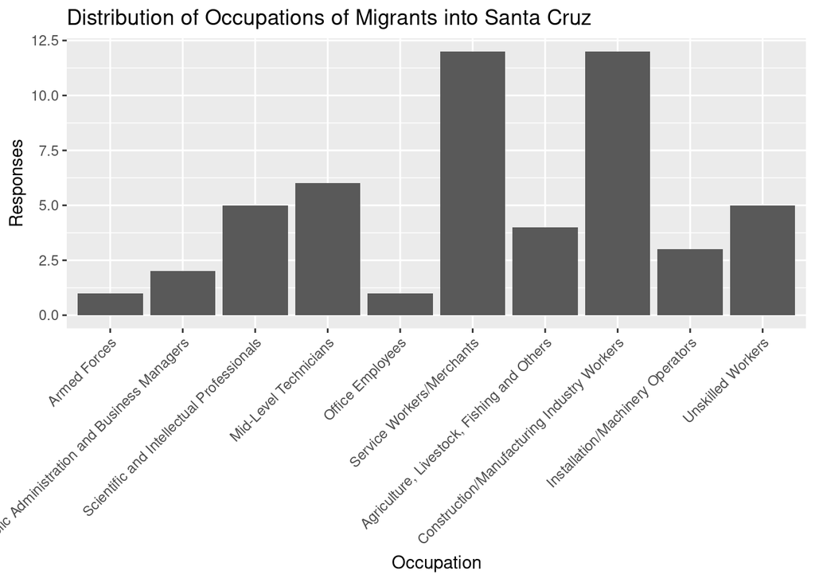

Figure 48: Distribution of Occupations of Migrants into Santa Cruz.

The graph above illustrates the distribution of occupations among migrants to Santa Cruz. The largest group of migrants falls under the category of “Service Workers/Merchants,” which perhaps indicates the appeal of Santa Cruz’s urban centers for commerce and service-related opportunities. This is followed closely by “Construction/Manufacturing Industry Workers”. It’s noteworthy that these top categories encompass a broad spectrum from urban to rural vocations, reflecting the diverse economic landscape of Santa Cruz.

As we delve deeper into the labor, employment, and income attributes of these migrants, we’ll gain a better understanding of their economic conditions and motivations. One place to start is looking at the range of monthly income of the migrants.

Table 7: Range of Monthly Income for Migrants into Santa Cruz

| Maximum | Minimum | Median | Mean |
| --- | --- | --- | --- |
| 15600 | 583.33 | 4700 | 6435.96 |

The range of monthly incomes among migrants moving into Santa Cruz showcases considerable diversity. The highest reported income stands at a substantial 15,600 Bs., while the lowest is just 583.33 Bs., indicating a wide economic spectrum among the migrants. The median income is 4,700 Bs., suggesting that the central tendency of incomes is considerably below the highest figures, yet still higher than the mininmun wage (2,250 Bs.). The mean income, calculated at 6,435.97 Bs., is higher than the median, hinting at the presence of some higher income values that pull the average up. Such disparities within the income range could be indicative of varied backgrounds, qualifications, and opportunities available to different migrants in Santa Cruz.

Let’s further explore the nuances of income by examining the average monthly earnings across different occupations.

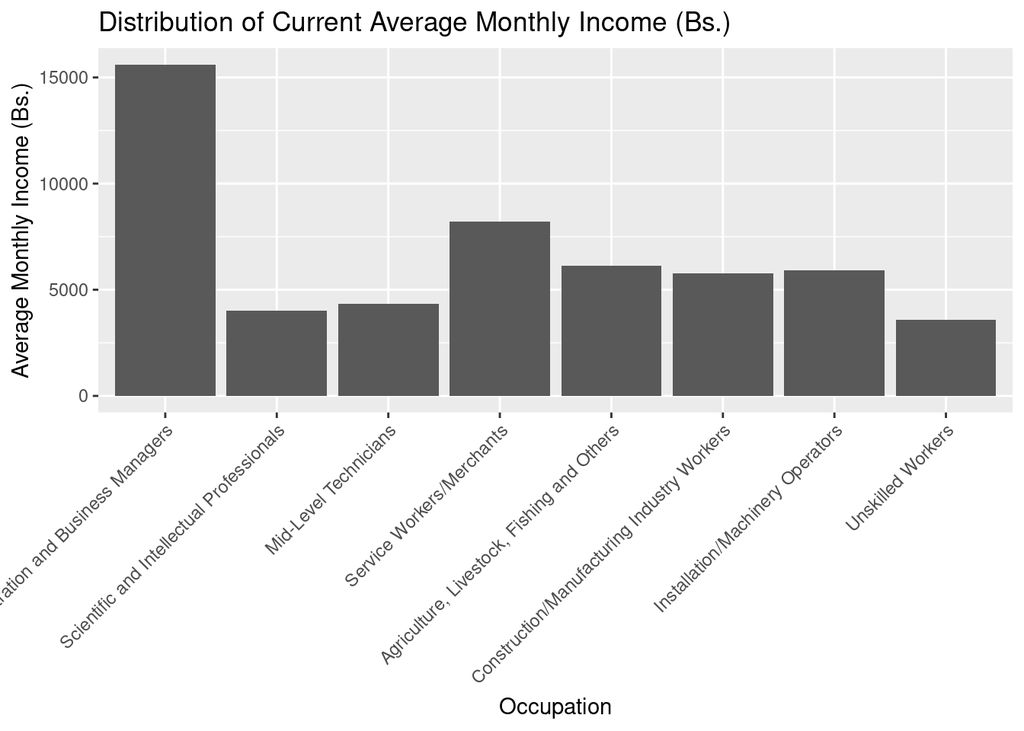

Figure 49: Current Average Monthly Income of Migrants into Santa Cruz by Occupation

#### Summary Conclusion of Migrants in Santa Cruz

In terms of occupations, while public administration and business management roles are less frequent, they yield the highest incomes, nearing 15,000 bs. This pronounced wage, especially among public officials, hints at potential economic disparities that could be rooted in systemic issues or even corruption. The service and merchant sectors follow suit with commendable earnings, while certain specialized roles, surprisingly, report modest incomes.

In the realm of income, Santa Cruz’s migrants demonstrate a wide range, from just over 583 bs to a significant 15,600 bs. The average monthly earnings of these migrants hover around 6,435 bs, with the median closer to 4,700 bs. These figures underscore the economic variability within the migrating population and hint at the diverse opportunities and challenges they might face in their new environment.

In summary, Santa Cruz stands as a microcosm of Bolivia’s broader migration patterns, reflecting both the hopes and complexities faced by its populace. The insights garnered here provide a foundation for understanding the economic, social, and cultural shifts taking place within Bolivia’s borders.

### Analysis Conclusion

#### Reiteration of Purpose

In this comprehensive analysis, our primary objective was to delve into the migratory patterns of Bolivians, both on a national and international scale. We sought to understand the nuances of migration, specifically focusing on variables like age, occupation, income, and reasons for migration. The primary dataset utilized encompassed responses from over 42,000 individuals, providing a rich source of insights. It’s crucial to note that this analysis was confined to the data available, with certain assumptions made, such as the normalization of income data and the exclusion of specific subsets of respondents to maintain clarity and relevance. This study offers a snapshot of migration in Bolivia, shedding light on the multifaceted reasons people move and the socioeconomic implications tied to it.

#### Key Findings

##### Demographics and Education

The analysis of education levels showcased some intriguing patterns, especially when dissected by gender. While education levels were generally consistent across genders, a surprising disparity emerged in the ‘No Education’ category, where females significantly outnumbered males. This discovery warranted a deeper dive, revealing factors such as rural residence and indigenous group affiliations as potential contributors.

Inter-departmental differences in education also presented noteworthy findings. Some departments exhibited higher levels of advanced education, while others had a greater proportion of residents with minimal formal education. This variance underscores the heterogeneous educational landscape across Bolivia, potentially influenced by regional socio-economic factors, access to educational resources, and cultural values.

##### Labor and Employment

In the realm of employment, Bolivians predominantly find themselves engaged in Service/Merchant roles, followed closely by occupations in Agriculture Labor and Construction/Manufacturing. This distribution offers a snapshot of Bolivia’s primary economic sectors and the labor market’s orientation.

When it comes to employment types, Self-Employment stands out as the predominant category, indicative of Bolivia’s entrepreneurial spirit and largely informal economy. However, it’s worth noting the substantial presence of Unpaid Laborers, particularly in the Agricultural sector, highlighting the familial or communal nature of some labor practices.

Income distribution presented a compelling narrative. While the median and mean incomes were encouragingly above the minimum wage, the disparity between the highest and lowest earners was remarkable. This inequality, influenced by factors such as occupation type and regional economic dynamics, emphasizes the need for a more in-depth analysis into wage structures and labor policies.

##### Migration Analysis

###### International Repatriation

The return of Bolivians from abroad provided intriguing insights into global migratory patterns. Predominantly, Argentina emerged as the principal country of origin, with a significant share of repatriates also hailing from other Hispanic countries, primarily in South America. A potential economic downturn in Argentina around 2016, marked by rising inflation, could partly elucidate this trend.

In terms of the reasons for their return, family considerations topped the list, underscoring the cultural and familial ties that bind Bolivians. However, education and employment opportunities also played a pivotal role in their decision to return.

Examining the demographics of this group, age patterns suggested a mix of potentially retired individuals returning from countries like the USA, Italy, and Paraguay, and younger cohorts, possibly students, from places like Ireland. When we consider their professional background, Service, Retail, and Construction/Manufacturing sectors dominate, reflecting the global job market’s orientation. In terms of income, while there’s a general uplift in earnings for those who spent time abroad, the range varies considerably based on the country of prior residence, with notable highs from countries like Spain and Italy.

###### Internal/National Migration

From an economic perspective, the occupation trends of migrants into Santa Cruz were diverse. While public administration roles fetched the highest salaries, sectors like service and merchant industries also played a significant role. However, the income disparities were evident, with certain professions, surprisingly including mid-level technicians and scientific roles, earning notably less.

#### Comparison and Synthesis

The juxtaposition of international repatriation and internal migration within Bolivia unveils a tapestry of movement that reflects both global trends and local dynamics. At the international level, the primary sources of repatriation were predominantly South American nations, with Argentina leading the way. The reasons for such movements, encompassing family ties and economic prospects, showcased the interplay of personal and professional motivations.

A shared theme across both migration types was the evident urbanization trend. Rural-to-urban migration, whether from international or national sources, echoed the global shift towards urban centers as hubs of opportunity and cultural exchange. However, income disparities remained a consistent undercurrent. While some professions, especially in public administration, drew high incomes in urban centers like Santa Cruz, others, surprisingly including roles that require specialized skills, lagged behind. This underscores the complexities of Bolivia’s economic landscape and the challenges and opportunities it presents to its migrating population.

#### Implications and Recommendations

The migration patterns and socio-economic dynamics unveiled in this analysis carry significant implications for various stakeholders in Bolivia:

##### For Policymakers:

**Education Disparities:** The surprisingly high numbers in the ‘No Education’ category, especially among women in rural areas, signals an urgent need for interventions in the educational sector. Policymakers might consider boosting educational outreach and infrastructural development in remote areas.

**Income Disparities:** The pronounced income disparities, particularly evident in urban centers like Santa Cruz, underscore the necessity for wage regulations and perhaps a region-specific re-evaluation of the minimum wage, where areas with higher economic output might warrant a higher minimum wage compared to other regions. Additionally, the potential economic disparity highlighted by the high incomes of public administrators demands transparency in public sector wages.

**Urbanization Trend:** The consistent migration towards urban centers underscores the need for proactive urban planning and infrastructural development to accommodate this growing population. Ensuring the quality of life remains high is paramount. Simultaneously, as we channel resources into urban development, it’s equally vital to allocate special care and support for rural areas, aiming to preserve their cultural significance and heritage.

##### For Businesses:

**Labor Market Dynamics:** Understanding the primary occupations of Bolivians, especially in burgeoning urban centers, can guide businesses in tailoring their services or products. For instance, the dominance of service and merchant roles in Santa Cruz offers potential business avenues.

**Investment Opportunities:** The income profiles of different departments and the evident disparities present both challenges and opportunities. Businesses can find niches in underserved markets or align their strategies with the higher income segments in urban areas.

##### For the General Population:

**Awareness and Advocacy:** The populace, equipped with this data, can advocate for better policies, especially in education and wage regulations. Grassroots movements can leverage these insights to push for change in specific sectors or regions.

**Migration Decisions:** Those considering migration, be it international or national, can make informed decisions based on the patterns and socio-economic profiles highlighted in this analysis.

In conclusion, while the data offers a snapshot of the current dynamics, it’s a clarion call for strategic interventions and informed decision-making across all sectors of Bolivian society.

#### Future Research and Limitations

Every comprehensive analysis is bound by certain constraints, and this study is no exception:

##### Limitations:

**Data Scope:** The dataset, while extensive, captures a specific time frame and may not reflect long-term trends or sudden shifts in migration patterns or socio-economic dynamics.

**Assumptions Made:** Some assumptions, particularly regarding income normalization and the filtering out of certain data points, may impact the granularity and nuance of the insights.

**Response Bias:** It’s worth noting that the data is based on responses, and there might be inherent biases. For instance, certain groups might be underrepresented due to lack of access or willingness to participate in such surveys.

##### Future Research Recommendations:

**Timescale Analysis:** A study that tracks changes over multiple years could provide richer insights into evolving trends.

**Qualitative Insights:** While this analysis is quantitative, qualitative studies, such as interviews or focus groups, could delve deeper into the reasons behind certain trends, particularly migration decisions.

**Economic Analysis:** A more in-depth economic analysis could provide context to the income disparities observed, considering factors like inflation rates, cost of living, and regional economic policies.

**Urbanization Deep Dive:** Given the evident urbanization trend, a dedicated study on urban development, housing, and infrastructure could be invaluable for policymakers and urban planners.

Building upon these findings and addressing the noted limitations can pave the way for an even more nuanced understanding of Bolivia’s socio-economic and migratory landscape.

#### Concluding Thoughts

As we draw this analytical journey to a close, it’s evident that Bolivia’s migratory patterns, both internal and international, are intricate confluence of socio-economic, educational, and labor influences. From the bustling urban centers to the tranquil rural landscapes, Bolivia’s dynamic population movements tell a story of aspiration, necessity, and the relentless search for better opportunities.

This analysis has not just been about numbers and charts; it’s about understanding the motivations that drive thousands to change their lives, seeking new horizons or returning to familiar ones. The implications of these movements ripple through every facet of Bolivian society, impacting its economy, culture, and future trajectory.

Migration, at its core, is a reflection of a nation’s pulse, its challenges, and its potential. By studying these patterns, we don’t just gain insight into where people are going, but also where Bolivia might head in the coming years. As we look ahead, it’s crucial to harness the insights from this analysis to shape a future that acknowledges these movements, learns from them, and ultimately, creates an environment where every Bolivian finds their place and purpose.

### Personal Learning

#### What I Learned

##### Technical Learning Curve

Navigating the data landscape of the Bolivian government’s websites and data repositories was an enlightening experience, introducing me to unique data structures, notably the SPSS format, as well as a treasure trove of publicly available datasets hosted by the Bolivian government. My challenge was twofold: understanding this new format and then harnessing appropriate libraries to translate it into a more familiar analytical framework. This project marked my inaugural foray into R programming. Transitioning from a Python-centric background, equipped with the Pandas library, to the distinct syntax and methodologies of R was akin to switching linguistic gears — demanding yet deeply enriching.

##### Deepening Domain Understanding

Born and raised in Bolivia, I entered this project with a sense of familiarity, drawing largely from personal experiences, familial anecdotes, and selective media exposure. However, the data often painted a picture that diverged from my preconceived notions. While my roots provided a nuanced lens through which I interpreted the data, the findings frequently invited surprise, challenging my assumptions and enriching my understanding of Bolivia’s socio-economic, educational, labor, and migratory landscape.

##### Analytical Insights: Rethinking Assumptions on Santa Cruz

My initial hypothesis leaned towards a dominant inflow into Santa Cruz, given its economic reputation. Yet, the data unveiled a revelation: Santa Cruz experienced the most pronounced net negative migration compared to other departments. While the economic vitality of Santa Cruz was evident in the data, the exodus was an unexpected twist. Additionally, contrary to my anticipation of a robust agricultural sector, the industry’s presence was less pronounced than imagined.

#### Navigating the Challenges

Embarking on this project presented a series of hurdles. A primary obstacle was transitioning from my comfort zone with Python to grappling with R, a programming language new to me. The dataset itself posed its own set of challenges: its unique format, primarily numerical, required extensive translation and interpretation, often making the process repetitive and intricate. The use of dictionary keys to represent string data added another layer of complexity. Analytical constraints also emerged due to the limited sample size in the survey and the inherent limitations of relying on a single data source. An additional consideration was that the survey’s structure captured household responses rather than individual perspectives, which could potentially skew certain interpretations.

In response to these challenges, a multifaceted approach was essential. Migrating from Python to R required extensive research, consultations with R documentation, and trial-and-error iterations. To tackle the data’s unique format, I leveraged specialized libraries to convert numerical representations into comprehensible insights. When faced with potential data biases due to the survey’s household-centric approach, I took extra care in the interpretation phase, frequently cross-referencing findings and maintaining a critical lens throughout. Each challenge, in turn, became an opportunity for growth and innovation.

#### What I Would Do Differently

**Enhancing with Historical Data:** In hindsight, integrating data from prior surveys could have enriched the analysis, offering a clearer year-to-year evolution of migratory trends instead of relying solely on the five-year retrospective responses. Such an approach would not only chart the shifts in migratory patterns but also provide a detailed trajectory of changes in occupations, income trajectories, and educational attainments over an extended period.

**Focused Analytical Scope:** In reflection, refining the scope to be more specific could have been beneficial. Migration trends are influenced by a multitude of factors, making them inherently complex. A more narrowed focus would have allowed for a sharper, more detailed exploration, providing insights that are both concise and pinpointed.

**Diverse Data Visualization:** In hindsight, diversifying the types of visual representations would have enhanced the presentation of my findings. While the frequent use of bar plots was partly influenced by the nature of the data and my nascent familiarity with the programming language, there’s a clear opportunity for future projects to employ a wider array of visualization tools for a more dynamic and comprehensive portrayal of data.

#### Future Prospects

This analysis serves not only as a comprehensive review but also as a springboard for more intricate inquiries. Specifically, the sections on income and occupation present intriguing questions that warrant more detailed and focused examinations. The foundation has been laid, opening avenues for further in-depth exploration in the future.

## Thank you

#### Contact Information

Wesley Ordoñez +1 (708) 669-9225 wesordonez1@gmail.com Chicago, IL